# Losing weight

Jim S

7/5/2021

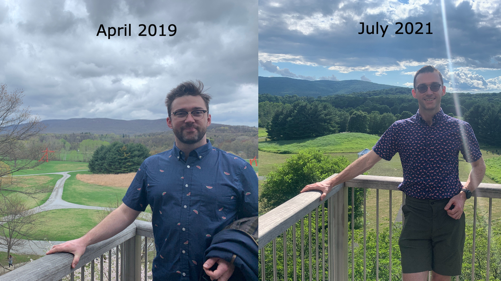

From succulent to skinny Jim

Over the past couple of years, my weight has dropped from roughly 97.5kg (215lbs) to 74kg (163lbs). On Saturday I ran a mile in 5:48 (not club runner speed, but unthinkable a few years ago). I hit my goal weight of 73.5kg—my weight before meeting Sue in my 3rd year of undergrad in 2008—a couple of months ago and thought I’d write a post on the experience if I was able to keep the weight off.

I found the following helpful: some combination of 16:8 or 18:6 intermittent fasting, daily weigh-ins, calorie counting, a large increase in greens and fruit in my diet, reducing alcohol, and high intensity cardio exercise, especially running intervals with friends. Probably sleep also. The things I found unhelpful and unsustainable were: meal substitutes like Soylent and Huel, keto-ish diet, prepped low-calorie meals, exercise aside from high intensity cardio, and longer fasts.

If you are looking to get in shape and forced me to make some suggestions, they would be: sign up to Noom AND get a fitness tracker like a Garmin running watch (or WHOOP) and sign up to one of the Coach plans, or sign up to a fitness class like Orange Theory. Even for the best classes, apps, devices, the honeymoon always fades. The reason I suggest these over others is that at least for me, they very neatly link a sustainable change in behavior to observable progress.

## Gaining weight

I gained weight by not understanding nutrition very well, and by generating a bad series of habits around working or studying very late into the night. My previous lifestyle looked like:

- Wine with very calorie-dense dinner most nights
- Working as a modeler or researcher, which meant little progress during the day, being plagued by guilt for not having gotten much done during the day leading to long hours at night trying to make up for lack of productivity
- Having a young child who didn’t sleep
- Being constantly tired due to ^^, not having energy for exercise in the morning
- Enjoying cheap New York food a bit too much (lamb and chicken over rice with all the white sauce @ 1200 calories; BEC on a roll at 700, and so on)

When I started at Schmidt Futures, things went into overdrive. My initial role was as a grantmaker, which means constant travel, being fed, the double airport + aircraft breakfast, hotel buffets and so on. When in the office, afternoon “healthy snacks” looked like some Greek yoghurt and 300 calories of cranberries and nuts. There’s almost no exercise plan in which that works.

Then a few things started to slip. I started tearing trousers and shirts while doing up my laces. The doorman at our office started calling me “big guy”. The real moment came when I saw the video of a talk I gave at the NYC R Conference. This big guy was just not the person I was in my mind.

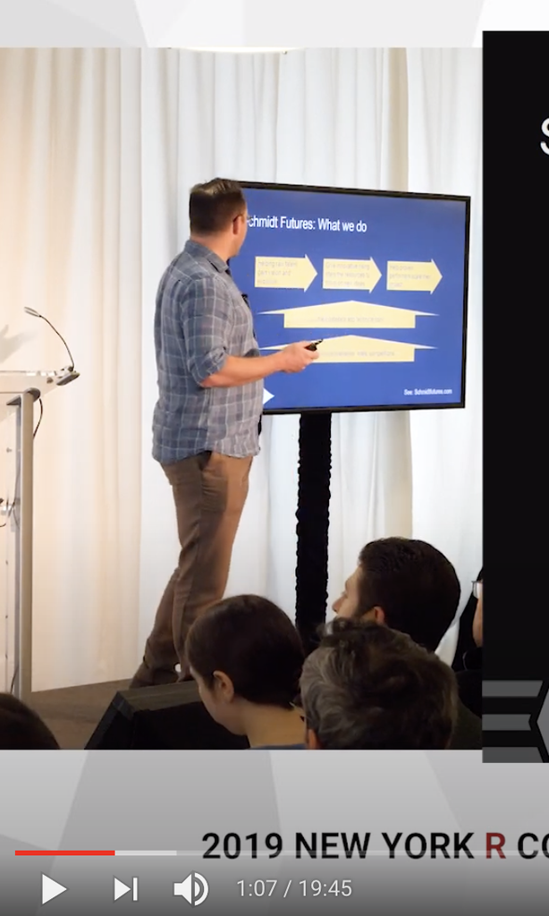

Always be integrating over your enormous posterior

The afternoon I saw the video above–June 19, 2019–I walked into Orange Theory, across the road from work, and signed up. Scott Cunningham had been posting about them a lot on Twitter, and I thought “can’t hurt, might help”. I also started following a few Reddit weightloss groups—`r/intermittentfasting` in particular. That was the start of experimentation with a few dozen approaches to weightloss, the best reviewed below.

## Things that worked, chronological order

### Orange Theory (June 2019-March 2020), B+

Orange Theory is a group fitness class centered on a 1h high-intensity cardio workout that includes treadmill, rowing and dumbbell/bodyweight exercises.

It has a couple of gamification elements that work nicely. The first is that it’s quite expensive, and each level of membership gives you access to a fixed number of classes per month. You register for these ahead of time, and if you don’t show up, you lose your credit. For me, that solved the problem of a continuous gym membership that I never ended up using. Per visit, it’s the cheapest gym I’ve belonged to.

The second is that you wear a heart rate monitor while exercising, and your heart rate is broadcast on a screen. During the workout, you earn “splat points” for having your heartrate in the “orange zone”. For people who aren’t extremely fit, it’s frighteningly easy to get your heartrate this high for an extended period. So you walk out of your first few classes having earned 40 points and seeing all the regulars (fit people) with 15 points. A huge psychic boost!

Ultimately I stopped going as the pandemic got started. There were a few things about it that ticked me off: pretend fitness science, crappy showers and expense. But it’s a supportive environment that helps build confidence and fitness.

### Intermittent fasting (June 2019-present) A

Intermittent fasting involves not eating for some time, typically by restricting eating inside a window. Common fasts include “16:8”, in which you have a window of 8 hours a day in which you can eat, “18:6”, when the window is only 6 hours a day, or “5:2”, in which you eat normally for 5 days a week and not at all for two days.

There are thoughts on whether and why IF works. On the (maybe pseudo-)scientific end, advocates claim that fasting induces ketosis and autophagy. Ketosis is the state in which your body doesn’t have enough carbohydrates to burn, and so convert fat to ketones, which it uses for fuel. Autophagy is when your body clears out damaged cells, typically due to some stress–in this case, starvation. [In mouse models](https://www.sciencedirect.com/science/article/pii/S1550413117306083), keeping food intake fixed but restricting eating to intervals increased autophagy and reduced biomarkers that correspond to metabolic disorder in humans. In yeast, worm and mouse models, intermittent fasting led to [longer lives](https://onlinelibrary.wiley.com/doi/pdfdirect/10.1111/acel.12338). So there might be something in this research. But count me as skeptical.

Another take is that intermittent fasting works just because people who do it tend to consume fewer calories overall, which leads to weight loss [and other benefits](https://faculty.biu.ac.il/~cohenh6/publications/calorieRestrictionFull.pdf). This view is supported by [meta-analysis](https://eprints.gla.ac.uk/156472/7/156472.pdf) of multi-arm experiments in which IF is compared to calorie restriction (but not IF) diets and no-diet control. Put plainly: for weight loss, dieting or IF both seem to reduce weight more than not dieting, but IF does not systematically beat plan dieting.

My own experience with IF involved removing breakfast from my diet, and eating dinner a little earlier. This fit 16:8 pretty well. Now, most days—but not religiously—I eat lunch quite late (around 2 or so) and will have finished dinner at 7.30, meaning I mostly keep within 18:6. An exception is on days I have a long run, where a big breakfast is necessary. There are loads of intermittent fasting apps on the app store. I tried a few of these, but didn’t find I needed them.

I’ll probably do 16:8 or 18:6 for the rest of my life. It’s convenient, and makes it fairly easy to keep weight off.

### Calorie counting (March 2020-August 2020; Feb 2021-May 2021) B

Calorie counting involves keeping tabs on your calories. It’s easily the most effective way I found of losing weight quickly, yet I did not find it sustainable. I do not believe that calorie counting by itself would be sufficient for me to keep weight off long-term. If you’ve an event coming up and need to slim down, however, it would be my first suggestion.

The superb app [Lose It](http://fbuy.me/v/jim_6592) definitely helps, by making it fairly easy to log meals using its incredible food database (including barcode recognition and OCR on nutrition labels). Noom also encourages calorie counting (will discuss Noom in a minute).

### Noom (Feb 2021-July 2021) A+

[Noom](https://www.talkable.com/x/ktIaJE) is a fairly pricey mindfulness app that combines daily weight tracking, calorie counting, coaching, group support and mindfulness training. From February to May 2021, it was what I looked at for the first 15 minutes of every day. I believe it has given me a few skills that will have long-lasting effects on my health and weight. Their approach is to promote:

1. Starting each day with a recorded weigh-in, which keeps progress front-of mind
2. Pivoting towards a diet made up of foods with low caloric density, but not eliminating “fun” foods
3. Encouraging a mindset of “back on the wagon”, not catastrophizing after slip-ups
4. Working through a cringe-worthy if fun set of modules inspired by nutrition research, mindfulness, Cognitive Behavioral Therapy (CBT) and Dialectical Behavior Therapy (DBT). These modules encourage taking an outside view on triggers, feelings, behaviors and responses, especially around eating
5. Checking in with a group of people who are roughly at the same point of their Noom course, and
6. Having access to a coach if necessary.

I found the peer support group aspects fairly unnecessary; these could be improved by grouping together people within similar age and fitness groups. I also found the idea of a coach who would reach out to “check in”, very awkward. Others presumably enjoy those features though.

Other issues include its calorie-counting tool, which sorely lags Lose It’s. They rely on apparently unmoderated community submissions, which results in some fairly whacky calorie counts for some normal-ish foods.

### Garmin running watch and Garmin Coach (April 2021-present) A+

During the pandemic, my friend Andrew Whitby started to get me to join him at the Red Hook track for interval training. Andrew has a Garmin watch and mentioned in classic Andrew Whitby resignation that it was indeed OK.

Garmin watches combine a quite accurate GPS with heart-rate monitor and a bunch of other tracking features—like a sleep monitor—which are actually quite useful. The best feature I’ve found is the “coach” which prescribes a series of runs each week to focus on particular skills. Where it excels is in giving both positive feedback and negative: things like “you’re exercising too hard and probably going backwards”; “you’re running too fast given your run yesterday—slow down.”

Garmin watches integrate nicely with Strava, which makes social logging easy, and through their Connect app with Apple Health and Noom/Lose It, making calorie tracking easier. Unlike Apple watches (which do these things too) they work very nicely when you’re sweaty too: no touch-screen, and a small number of very easy-to-use buttons. I love mine.

### Let’s go for a run

If you’re in the New York City area and game for a run around Central Park, send me an email!